# About Aerofit

# For correlation: Heatmaps, Pairplots

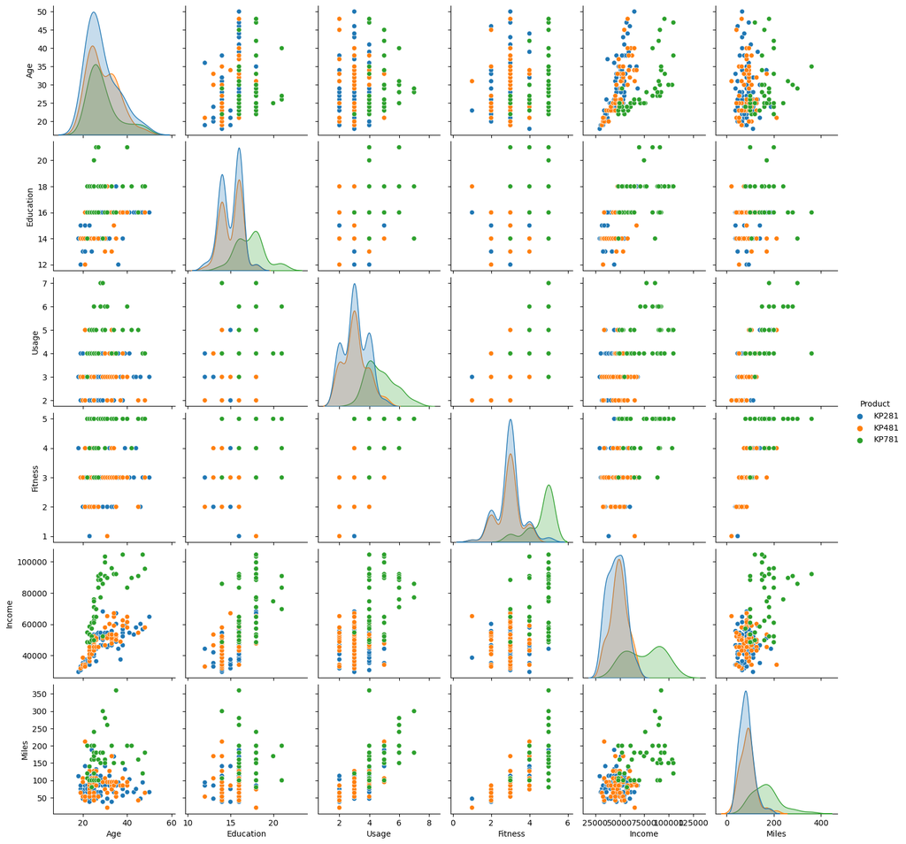

```python
sns.pairplot(df,hue="Product")
```

# LINEPLOT against follwing features for deeper anlysis.

- Product
- Age
- Gender
- Fitness
- Income
- Miles

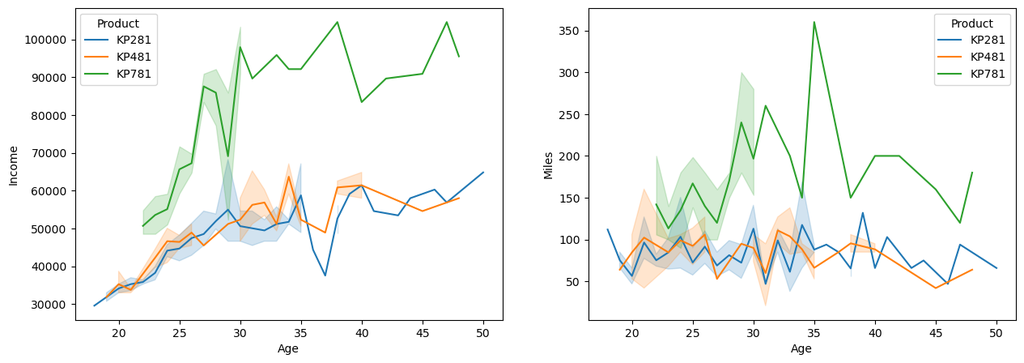

```python
fig, axes = plt.subplots(1, 2, figsize=(15, 5))
sns.lineplot(x='Age',data = df, y = 'Income' , hue = 'Product',ax=axes[0])
sns.lineplot(x='Age',data = df, y = 'Miles' , hue = 'Product',ax=axes[1])
plt.show()
```

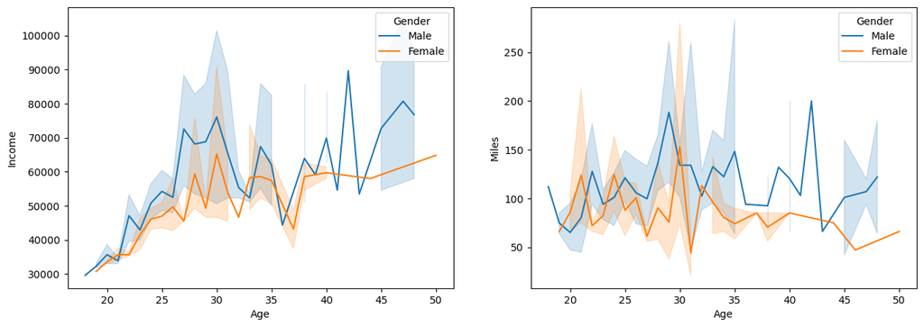

```python
fig, axes = plt.subplots(1, 2, figsize=(15, 5))
sns.lineplot(x='Age',data = df, y = 'Income' , hue = 'Gender',ax=axes[0])
sns.lineplot(x='Age',data = df, y = 'Miles' , hue = 'Gender',ax=axes[1])
plt.show()
```

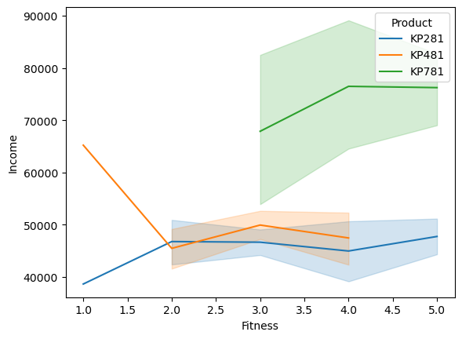

```python
sns.lineplot(x='Fitness',data = df, y = 'Income' , hue = 'Product')
plt.show()
```

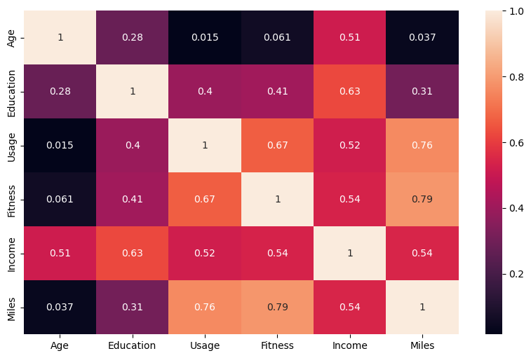

```python
data_numeric = df.select_dtypes(include=['float64', 'int64'])

plt.figure(figsize=(10, 6))
sns.heatmap(data_numeric.corr(),annot = True)
plt.show()
```

### Insights:

- Miles<->Fitness, Miles <-> Usage and Fitness<->Usage are highly correlated, which is an obvious trend as the more you use more miles you clock and more you will be fit.
- Education and Income also showing a strong correlation which is again an obvious trend.
- No corelation observed between Age<->Usage, Age<->Fitness or Age<->Miles which indicates age is not a barrier to use treadmills to get fit.
- Income is also co-related with Fitness/miles/usage which suggests if people are earning more then they are thinking of spending more on fitness.

# Observations

###### Product vs Age

- Customers purchasing products KP281 & KP481 are having same Age median value.
- Customers whose age lies between 25-30, are more likely to buy KP781 product ###### Product vs Education
- Customers whose Education is greater than 16, have more chances to purchase the KP781 product.
- While the customers with Education less than 16 have equal chances of purchasing KP281 or KP481. ##### Product vs Usage
- Customers who are planning to use the treadmill greater than 4 times a week, are more likely to purchase the KP781 product.
- While the other customers are likely to purchasing KP281 or KP481. ##### Product vs Fitness
- The more the customer is fit (fitness >= 3), higher the chances of the customer to purchase the KP781 product. ##### Product vs Income
- Higher the Income of the customer (Income >= 60000), higher the chances of the customer to purchase the KP781 product. ###### Product vs Miles
- If the customer expects to walk/run greater than 120 Miles per week, it is more likely that the customer will buy KP781 product.

# Creating contingency tables and calculating probabillities

- Computing Marginal & Conditional Probabilities

```python
# contingency table describing the frequencines of sales by the customer's gender and the type of treadmill purchased.
pd.crosstab(index = df.Gender,columns=df.Product,margins = True,margins_name = 'Totals')
```

| Product Gender | KP281 | KP481 | KP781 | Totals |
| --- | --- | --- | --- | --- |
| Female | 40 | 29 | 7 | 76 |
| Male | 40 | 31 | 33 | 104 |
| Totals | 80 | 60 | 40 | 180 |

```python
pd.crosstab(index = df.Gender,columns=df.Product,margins = True,margins_name = 'Totals',normalize= True)*100
```

| Product Gender | KP281 | KP481 | KP781 | Totals |
| --- | --- | --- | --- | --- |
| Female | 22.222222 | 16.111111 | 3.888889 | 42.222222 |
| Male | 22.222222 | 17.222222 | 18.333333 | 57.777778 |
| Totals | 44.444444 | 33.333333 | 22.222222 | 100.000000 |

###### Insights

From the above table we can see both marginal and joint probabilities.

##### Marginal Probability:

Percentage of KP281, KP481 and KP781 sales is 44.44%, 33.33% and 22.22% respectively Percentage of Males using Aerofit Products is 57.78% and females is 42.22%

##### Joint Probability:

- Fercentage of females buying KP781 is 3.89% ((7/180)x100)
- Fercentage of males and females buying KP281 is same Le. 22.22%

##### Conditional Probability:

Probability that the purchase will be a certain product given that the customer is female.

Given a Product sale, what is the probability that the purchaser is a male | female | parterend | single

```python
print("\033[1mProbability that the purchase will be a certain product given that the customer is Female:\033[1m")

print("\n")
print("P(KP281|Female)",round((40/76)*100, 2))
print("P(KP481|Female)",round((29/76)*100, 2))
print("P(KP781|Female)",round((7/76)*100, 2))

print("\n")

print("\033[1mProbability that the purchase will be a certain product given that the customer is Male:\033[1m")

print("\n")
print("P(KP281|Male)",round((40/104)*100, 2))
print("P(KP481|Male)",round((31/104)*100, 2))
print("P(KP781|Male)",round((33/104)*100, 2))
```

```
Probability that the purchase will be a certain product given that the customer is Female:


P(KP281|Female) 52.63
P(KP481|Female) 38.16
P(KP781|Female) 9.21


Probability that the purchase will be a certain product given that the customer is Male:


P(KP281|Male) 38.46
P(KP481|Male) 29.81
P(KP781|Male) 31.73
```

```python
print("\033[1mGiven a product sale , what is the probability that the purchaser  is Male :\033[1m")

print("\n")
print("P(Male|KP281)",round((40/80)*100, 2))
print("P(Male|KP481)",round((31/60)*100, 2))
print("P(Male|KP781)",round((33/40)*100, 2))

print("\n")
print("\033[1mGiven a product sale , what is the probability that the purchaser  is Female:\033[1m")
print("\n")
print("P(Female|KP281)",round((40/80)*100, 2))
print("P(Female|KP481)",round((29/60)*100, 2))
print("P(Female|KP781)",round((7/40)*100, 2))
```

```
Given a product sale , what is the probability that the purchaser  is Male :


P(Male|KP281) 50.0
P(Male|KP481) 51.67
P(Male|KP781) 82.5


Given a product sale , what is the probability that the purchaser  is Female:


P(Female|KP281) 50.0
P(Female|KP481) 48.33
P(Female|KP781) 17.5
```

#### Insights:

- Males are mostly using Aerafit products with KP781 most popular as the Probability that a customer is male given that the product is KP781 is 82.5%.
- KP781 is not a popular product among females as only 3.89% females are buying it and probability that the purchase will be KP781 given that the customer is female is only 9.21%.

```python
# Contingency table describing the frequencies of sales by the customer's marital status and the type of treadmill purchased
pd.crosstab(index = df.MaritalStatus,columns=df.Product,margins = True,margins_name = 'Totals')
```

| Product MaritalStatus | KP281 | KP481 | KP781 | Totals |
| --- | --- | --- | --- | --- |
| Partnered | 48 | 36 | 23 | 107 |
| Single | 32 | 24 | 17 | 73 |
| Totals | 80 | 60 | 40 | 180 |

```python
pd.crosstab(index = df.MaritalStatus,columns=df.Product,margins = True,margins_name = 'Totals',normalize = True)*100
```

| Product MaritalStatus | KP281 | KP481 | KP781 | Totals |
| --- | --- | --- | --- | --- |
| Partnered | 26.666667 | 20.000000 | 12.777778 | 59.444444 |
| Single | 17.777778 | 13.333333 | 9.444444 | 40.555556 |
| Totals | 44.444444 | 33.333333 | 22.222222 | 100.000000 |

```python
print("\033[1mProbability that the purchase will be a certain product given that the customer is Partnered:\033[1m")

print("\n")
print("P(KP281|Partnered)",round((48/107)*100, 2))
print("P(KP481|Partnered)",round((36/107)*100, 2))
print("P(KP781|Partnered)",round((23/107)*100, 2))
print("\n")

print("\033[1mProbability that the purchase will be a certain product given that the customer is Single	:\033[1m")

print("\n")
print("P(KP281|Single)",round((32/73)*100, 2))
print("P(KP481|Single)",round((24/73)*100, 2))
print("P(KP781|Single)",round((17/73)*100, 2))
print("\n")

print("\033[1mGiven a product sale , what is the probability that the purchaser  is Partnered :\033[1m")

print("\n")
print("P(Partnered|KP281)",round((48/80)*100, 2))
print("P(Partnered|KP481)",round((36/60)*100, 2))
print("P(Partnered|KP781)",round((23/40)*100, 2))

print("\n")
print("\033[1mGiven a product sale , what is the probability that the purchaser  is Single:\033[1m")
print("\n")
print("P(Single|KP281)",round((32/80)*100, 2))
print("P(Single|KP481)",round((24/60)*100, 2))
print("P(Single|KP781)",round((17/40)*100, 2))
```

```
Probability that the purchase will be a certain product given that the customer is Partnered:


P(KP281|Partnered) 44.86
P(KP481|Partnered) 33.64
P(KP781|Partnered) 21.5


Probability that the purchase will be a certain product given that the customer is Single	:


P(KP281|Single) 43.84
P(KP481|Single) 32.88
P(KP781|Single) 23.29


Given a product sale , what is the probability that the purchaser  is Partnered :


P(Partnered|KP281) 60.0
P(Partnered|KP481) 60.0
P(Partnered|KP781) 57.5


Given a product sale , what is the probability that the purchaser  is Single:


P(Single|KP281) 40.0
P(Single|KP481) 40.0
P(Single|KP781) 42.5
```

```python
# Contingency table describing the frequencies of sales by the customer's Income Group and the type of treadmill purchased
pd.crosstab(index = df.Income_Group,columns=df.Product,margins = True,margins_name = 'Totals')
```

| Product Income_Group | KP281 | KP481 | KP781 | Totals |
| --- | --- | --- | --- | --- |
| Lower Income | 48 | 30 | 5 | 83 |
| Middle Income | 32 | 30 | 14 | 76 |
| Upper Income | 0 | 0 | 21 | 21 |
| Totals | 80 | 60 | 40 | 180 |

```python
pd.crosstab(index = df.Income_Group,columns=df.Product,margins = True,margins_name = 'Totals',normalize = True)*100
```

| Product Income_Group | KP281 | KP481 | KP781 | Totals |
| --- | --- | --- | --- | --- |
| Lower Income | 26.666667 | 16.666667 | 2.777778 | 46.111111 |
| Middle Income | 17.777778 | 16.666667 | 7.777778 | 42.222222 |
| Upper Income | 0.000000 | 0.000000 | 11.666667 | 11.666667 |
| Totals | 44.444444 | 33.333333 | 22.222222 | 100.000000 |

```python
print("\033[1mProbability that the purchase will be a certain product given that the customer belongs to Lower Income:\033[1m")

print("\n")
print("P(KP281|Lower Income)",round((48/83)*100, 2))
print("P(KP481|Lower Income)",round((30/83)*100, 2))
print("P(KP781|Lower Income)",round((5/83)*100, 2))

print("\n")
print("\033[1mGiven a product sale , what is the probability that the purchaser belongd to Middle Income:\033[1m")
print("\n")
print("P(Middle Income|KP281)",round((32/80)*100, 2))
print("P(Middle Income|KP481)",round((30/60)*100, 2))
print("P(Middle Income|KP781)",round((14/40)*100, 2))
```

```
Probability that the purchase will be a certain product given that the customer belongs to Lower Income:


P(KP281|Lower Income) 57.83
P(KP481|Lower Income) 36.14
P(KP781|Lower Income) 6.02


Given a product sale , what is the probability that the purchaser belongd to Middle Income:


P(Middle Income|KP281) 40.0
P(Middle Income|KP481) 50.0
P(Middle Income|KP781) 35.0
```

##### Insights:

- Customers from "Upper Income Groups' are mostly buying the KP781 product with 11.67% probability
- Probability that the purchase will be KP781 treadmill given that customer belongs to 'Upper Income' Group is 100%.
- Lower Income group is mostly preferring KP281 with 26.67% probability which is expected as this is the cheapest model.

```python
# Contingency table describing the frequencies of sales by the customer's Age Group and the type of treadmill purchased
pd.crosstab(index = df.Age_Group_Names,columns=df.Product,margins = True,margins_name = 'Totals')
```

| Product Age_Group_Names | KP281 | KP481 | KP781 | Totals |
| --- | --- | --- | --- | --- |
| Young Adult | 53 | 33 | 27 | 113 |
| Middle-aged Adult | 20 | 22 | 8 | 50 |
| Old-age Adult | 7 | 5 | 5 | 17 |
| Totals | 80 | 60 | 40 | 180 |

```python
pd.crosstab(index = df.Age_Group_Names,columns=df.Product,margins = True,margins_name = 'Totals',normalize = True)
```

| Product Age_Group_Names | KP281 | KP481 | KP781 | Totals |
| --- | --- | --- | --- | --- |
| Young Adult | 0.294444 | 0.183333 | 0.150000 | 0.627778 |
| Middle-aged Adult | 0.111111 | 0.122222 | 0.044444 | 0.277778 |
| Old-age Adult | 0.038889 | 0.027778 | 0.027778 | 0.094444 |
| Totals | 0.444444 | 0.333333 | 0.222222 | 1.000000 |

```python
print("\033[1mProbability that the purchase will be a certain product given that the customer belongs to Middle-aged Adult:\033[1m")

print("\n")
print("P(KP281|Middle-aged Adult)",round((20/50)*100, 2))
print("P(KP481|Middle-aged Adult)",round((22/50)*100, 2))
print("P(KP781|Middle-aged Adult)",round((8/50)*100, 2))

print("\n")
print("\033[1mGiven a product sale , what is the probability that the purchaser belongs to Young Adult:\033[1m")
print("\n")
print("P(Young Adult|KP281)",round((53/80)*100, 2))
print("P(Young Adult|KP481)",round((33/60)*100, 2))
print("P(Young Adult|KP781)",round((27/40)*100, 2))
```

```
Probability that the purchase will be a certain product given that the customer belongs to Middle-aged Adult:


P(KP281|Middle-aged Adult) 40.0
P(KP481|Middle-aged Adult) 44.0
P(KP781|Middle-aged Adult) 16.0


Given a product sale , what is the probability that the purchaser belongs to Young Adult:


P(Young Adult|KP281) 66.25
P(Young Adult|KP481) 55.0
P(Young Adult|KP781) 67.5
```

```python
# Contingency table describing the frequencies of sales by the customer's Fitness and the type of treadmill purchased
pd.crosstab(index = df.Fitness,columns=df.Product,margins = True,margins_name = 'Totals')
```

| Product Fitness | KP281 | KP481 | KP781 | Totals |
| --- | --- | --- | --- | --- |
| 1 | 1 | 1 | 0 | 2 |
| 2 | 14 | 12 | 0 | 26 |
| 3 | 54 | 39 | 4 | 97 |
| 4 | 9 | 8 | 7 | 24 |
| 5 | 2 | 0 | 29 | 31 |
| Totals | 80 | 60 | 40 | 180 |

```python
pd.crosstab(index = df.Fitness,columns=df.Product,margins = True,margins_name = 'Totals',normalize = True)*100
```

| Product Fitness | KP281 | KP481 | KP781 | Totals |
| --- | --- | --- | --- | --- |
| 1 | 0.555556 | 0.555556 | 0.000000 | 1.111111 |
| 2 | 7.777778 | 6.666667 | 0.000000 | 14.444444 |
| 3 | 30.000000 | 21.666667 | 2.222222 | 53.888889 |
| 4 | 5.000000 | 4.444444 | 3.888889 | 13.333333 |
| 5 | 1.111111 | 0.000000 | 16.111111 | 17.222222 |
| Totals | 44.444444 | 33.333333 | 22.222222 | 100.000000 |

```python
# Contingency table describing the frequencies of sales by the customer's usage per week type of treadmill purchased
pd.crosstab(index = df.Gender,columns=df.Usage,margins = True,margins_name = 'Totals')
```

| Usage Gender | 2 | 3 | 4 | 5 | 6 | 7 | Totals |
| --- | --- | --- | --- | --- | --- | --- | --- |
| Female | 20 | 33 | 14 | 7 | 2 | 0 | 76 |
| Male | 13 | 36 | 38 | 10 | 5 | 2 | 104 |
| Totals | 33 | 69 | 52 | 17 | 7 | 2 | 180 |

```python
pd.crosstab(index = df.Gender,columns=df.Usage,margins = True,margins_name = 'Totals',normalize = True)*100
```

| Usage Gender | 2 | 3 | 4 | 5 | 6 | 7 | Totals |
| --- | --- | --- | --- | --- | --- | --- | --- |
| Female | 11.111111 | 18.333333 | 7.777778 | 3.888889 | 1.111111 | 0.000000 | 42.222222 |
| Male | 7.222222 | 20.000000 | 21.111111 | 5.555556 | 2.777778 | 1.111111 | 57.777778 |
| Totals | 18.333333 | 38.333333 | 28.888889 | 9.444444 | 3.888889 | 1.111111 | 100.000000 |

# Recommendations

### Target Upper income groups

- Median Income of Aerofit customers is 48891 USD which says that Aerofit customers fall into lower to middle income group,Also 88% of Aerofit customers fall in Lower to Middle Income group (customized group based on Aerofit dataset) le, from 29K to 75K USD.
- So, Aerofit should target to have considerable customer base from Upper Income groups maybe by launching a high-end product or marketing more to high-income people.

### Increase sales among female customers

- 42% of Aerofit customers are females and also, we have seen males are mostly using the Aerofit treadmills per week, Percentage of females using the Aerofit treadmills more than 3 days per week is very low compared to males.
- It has been observed that Males have rated themselves higher in fitness with 3.5 rating compared to females with 3.0 rating
- As age is increasing females are clocking less miles than males. There's a considerable dip in miles run/walk in 40-50 years females when compared to males
- So, Aerafit should focus on how to increase their sales to females more, maybe through advertising and also customizing/launching products suitable for females especially elderly females.

### Increase KP781 sales and bring it at par with other products

- KP781 sales is only at 22.22%
- A huge difference has been observed between males and females using the KP781 treadmill KP781 is not a popular product among females as only 3.89% females are buying it and probability that the purchase will be KP781 given that the customer is female is only 9.21%
- So Aerofit should inspect on why KP781 sales is very low among females and take necessary action to make it more suitable for both male and female customers Also KP781 is the least favorite among middle-aged adults (30-39 years) as they are using the other 2 products almost equally
- Probability that the purchase will be KP781 given that the customer is a Middle-Aged Adult stands at only 16% while the other 2 products KP281 and KP481 stands at 40% and 44% respectively. Even though middle-aged adults are in Middle or Upper income groups they are not preferring KP781 product So Aerofit should target middle-age adults between the age bracket 30-39 years to increase their KP781 sales.
- It has been observed that KP781 is being used by highly educated, belonging to upper income and fitness enthusiast/professional customers, so they should market this as their premium model and target this customer profile more.

### Boost KP481 sales among fitness-conscious customers

- KP481 treadmill is a premium model than KP281, but the average fitness rating of the customers using KP481(2.9) is little bit lower than KP281(2.96). In fact it is the lowest as KP781 average fitness rating is 4.62. So, it seems like there is some problem with this product where fitness enthusiasts or professionals are avoiding this product.
- Aerofit should do some survey, get customer feedback from these fitness-conscious (fitness rating 4 and 5) customers about any issues with this product and take necessary action to make it more popular among these customers.